# practica

```python
# Tensorflow and tf.keras
import tensorflow as tf
from tensorflow import keras
print("Tensorflow version:",tf.__version__)
print("Keras version:",keras.__version__)

#Helper libraries
import numpy as np
import pandas as pd
import matplotlib.pyplot as plt
```

[output not shown]

```
Tensorflow version: 2.20.0
Keras version: 3.13.2
```

```python
ATT_FILE = "FootballPlayerPreparedCleanAttributes.csv"
LABEL_FILE = "FootballPlayerOneHotEncodedClasses.csv"

attributes = pd.read_csv(ATT_FILE)
labels = pd.read_csv(LABEL_FILE)
```

```python
from sklearn import model_selection

RANDOM_STATE = 52

# Separamos en train/(validation+test)
train_x, val_and_test_x, train_y, val_and_test_y = model_selection.train_test_split(
    attributes,
    labels,
    random_state=RANDOM_STATE,
    shuffle=True,
    train_size=0.8
)

# Separamos en validation/test
validation_x, test_x, validation_y, test_y = model_selection.train_test_split(
    val_and_test_x,
    val_and_test_y,
    test_size=0.5, # 0.2 * 0.5 = 0.1 = 10%
    random_state=RANDOM_STATE
)
```

```python
print(f"{train_x.shape=} {train_y.shape=}")
print(f"{validation_x.shape=} {validation_y.shape=}")
print(f"{test_x.shape=} {test_y.shape=}")
```

```
train_x.shape=(12907, 22) train_y.shape=(12907, 4)
validation_x.shape=(1613, 22) validation_y.shape=(1613, 4)
test_x.shape=(1614, 22) test_y.shape=(1614, 4)
```

```python
train_x[:4]
```

|  | Crossing | Finishing | HeadingAccuracy | ShortPassing | Volleys | Dribbling | Curve | FKAccuracy | LongPassing | BallControl | ... | Stamina | Strength | LongShots | Aggression | Interceptions | Positioning | Vision | Penalties | Composure | Marking |
| --- | --- | --- | --- | --- | --- | --- | --- | --- | --- | --- | --- | --- | --- | --- | --- | --- | --- | --- | --- | --- | --- |
| 13432 | -0.073171 | -0.223529 | -0.063291 | 0.041096 | -0.275 | -0.108434 | -0.421687 | -0.285714 | 0.000000 | -0.060241 | ... | 0.130435 | -0.277778 | -0.253012 | 0.024390 | -0.195122 | 0.047619 | -0.048780 | -0.15 | -0.432432 | -0.404762 |
| 15228 | -0.560976 | -0.576471 | 0.012658 | -0.397260 | -0.400 | -0.638554 | -0.542169 | -0.476190 | -0.729730 | -0.469880 | ... | -0.826087 | -0.083333 | -0.614458 | 0.073171 | 0.146341 | -0.571429 | -0.439024 | -0.15 | -0.459459 | 0.166667 |
| 4934 | -0.634146 | -0.670588 | -0.113924 | -0.726027 | -0.675 | -0.590361 | -0.518072 | -0.571429 | -0.675676 | -0.590361 | ... | -0.043478 | 0.222222 | -0.831325 | -0.073171 | -0.048780 | -0.642857 | -0.414634 | -0.35 | -0.567568 | -0.095238 |
| 10769 | -0.317073 | -0.294118 | -0.113924 | 0.041096 | -0.500 | 0.156627 | -0.445783 | -0.452381 | 0.000000 | 0.036145 | ... | -0.188406 | 0.194444 | -0.421687 | 0.146341 | -0.243902 | -0.571429 | -0.048780 | -0.05 | -0.567568 | -0.071429 |

4 rows × 22 columns

```python
train_y[:4]
```

|  | Poor:[np.float64(46.0), np.float64(62.0)] | Interm:[np.float64(63.0), np.float64(66.0)] | Good:[np.float64(67.0), np.float64(71.0)] | Excel:[np.float64(72.0), np.float64(94.0)] |
| --- | --- | --- | --- | --- |
| 13432 | 1.0 | 0.0 | 0.0 | 0.0 |
| 15228 | 1.0 | 0.0 | 0.0 | 0.0 |
| 4934 | 1.0 | 0.0 | 0.0 | 0.0 |
| 10769 | 1.0 | 0.0 | 0.0 | 0.0 |

```python
INPUTS = train_x.shape[1]
OUTPUTS = train_y.shape[1]
```

```python
def visualize_history(history, ylim: tuple[float, float] = None):
    results=pd.DataFrame(history)
    results.plot(figsize=(8, 5))
    plt.grid(True)
    plt.xlabel("Epochs")
    plt.ylabel("Accuracy - Mean Log Loss")
    if ylim:
        plt.gca().set_ylim(*ylim)
    plt.show()
```

```python
n_epochs = 30
batch_size = 64
```

Antes de hacer un modelo profundo, vamos a ver a que rendimiento llegara un modelo sin capas ocultas

```python
from keras import layers
from keras import models

first_model = models.Sequential([
    layers.InputLayer(shape=[INPUTS]),
    layers.Dense(OUTPUTS, activation="softmax")
])
```

```
2026-03-17 12:32:11.508907: E external/local_xla/xla/stream_executor/cuda/cuda_platform.cc:51] failed call to cuInit: INTERNAL: CUDA error: Failed call to cuInit: CUDA_ERROR_NO_DEVICE: no CUDA-capable device is detected
```

Para optimizarlo, usaremos el descenso del gradiente y evaluamos su rendimiento

```python
from keras import losses
from keras import optimizers

first_model.compile(
    loss=losses.categorical_crossentropy,
    optimizer=optimizers.SGD(learning_rate=0.1),
    metrics=["categorical_accuracy"]
)

history = first_model.fit(
    train_x,
    train_y,
    batch_size=batch_size,
    epochs=n_epochs,
    verbose=1,
    validation_data=(validation_x, validation_y)
)
```

```
202/202 ━━━━━━━━━━━━━━━━━━━━ 0s 1ms/step - categorical_accuracy: 0.5055 - loss: 1.0906 - val_categorical_accuracy: 0.5704 - val_loss: 0.9555
202/202 ━━━━━━━━━━━━━━━━━━━━ 0s 753us/step - categorical_accuracy: 0.5895 - loss: 0.9084 - val_categorical_accuracy: 0.6057 - val_loss: 0.8848
202/202 ━━━━━━━━━━━━━━━━━━━━ 0s 785us/step - categorical_accuracy: 0.6066 - loss: 0.8596 - val_categorical_accuracy: 0.6218 - val_loss: 0.8493
202/202 ━━━━━━━━━━━━━━━━━━━━ 0s 736us/step - categorical_accuracy: 0.6220 - loss: 0.8313 - val_categorical_accuracy: 0.6231 - val_loss: 0.8246
202/202 ━━━━━━━━━━━━━━━━━━━━ 0s 762us/step - categorical_accuracy: 0.6331 - loss: 0.8110 - val_categorical_accuracy: 0.6311 - val_loss: 0.8086
202/202 ━━━━━━━━━━━━━━━━━━━━ 0s 761us/step - categorical_accuracy: 0.6411 - loss: 0.7957 - val_categorical_accuracy: 0.6367 - val_loss: 0.7932
202/202 ━━━━━━━━━━━━━━━━━━━━ 0s 783us/step - categorical_accuracy: 0.6470 - loss: 0.7829 - val_categorical_accuracy: 0.6435 - val_loss: 0.7802
202/202 ━━━━━━━━━━━━━━━━━━━━ 0s 763us/step - categorical_accuracy: 0.6537 - loss: 0.7723 - val_categorical_accuracy: 0.6485 - val_loss: 0.7724
202/202 ━━━━━━━━━━━━━━━━━━━━ 0s 789us/step - categorical_accuracy: 0.6586 - loss: 0.7635 - val_categorical_accuracy: 0.6640 - val_loss: 0.7623
202/202 ━━━━━━━━━━━━━━━━━━━━ 0s 731us/step - categorical_accuracy: 0.6608 - loss: 0.7556 - val_categorical_accuracy: 0.6603 - val_loss: 0.7544
202/202 ━━━━━━━━━━━━━━━━━━━━ 0s 753us/step - categorical_accuracy: 0.6643 - loss: 0.7488 - val_categorical_accuracy: 0.6634 - val_loss: 0.7469
202/202 ━━━━━━━━━━━━━━━━━━━━ 0s 717us/step - categorical_accuracy: 0.6686 - loss: 0.7424 - val_categorical_accuracy: 0.6658 - val_loss: 0.7421
202/202 ━━━━━━━━━━━━━━━━━━━━ 0s 741us/step - categorical_accuracy: 0.6707 - loss: 0.7369 - val_categorical_accuracy: 0.6727 - val_loss: 0.7356
202/202 ━━━━━━━━━━━━━━━━━━━━ 0s 762us/step - categorical_accuracy: 0.6743 - loss: 0.7320 - val_categorical_accuracy: 0.6758 - val_loss: 0.7310
202/202 ━━━━━━━━━━━━━━━━━━━━ 0s 756us/step - categorical_accuracy: 0.6770 - loss: 0.7274 - val_categorical_accuracy: 0.6770 - val_loss: 0.7261
202/202 ━━━━━━━━━━━━━━━━━━━━ 0s 765us/step - categorical_accuracy: 0.6785 - loss: 0.7233 - val_categorical_accuracy: 0.6733 - val_loss: 0.7218
202/202 ━━━━━━━━━━━━━━━━━━━━ 0s 755us/step - categorical_accuracy: 0.6821 - loss: 0.7195 - val_categorical_accuracy: 0.6770 - val_loss: 0.7189
202/202 ━━━━━━━━━━━━━━━━━━━━ 0s 777us/step - categorical_accuracy: 0.6831 - loss: 0.7161 - val_categorical_accuracy: 0.6751 - val_loss: 0.7157
202/202 ━━━━━━━━━━━━━━━━━━━━ 0s 780us/step - categorical_accuracy: 0.6834 - loss: 0.7130 - val_categorical_accuracy: 0.6844 - val_loss: 0.7119
202/202 ━━━━━━━━━━━━━━━━━━━━ 0s 784us/step - categorical_accuracy: 0.6851 - loss: 0.7098 - val_categorical_accuracy: 0.6795 - val_loss: 0.7098
202/202 ━━━━━━━━━━━━━━━━━━━━ 0s 794us/step - categorical_accuracy: 0.6889 - loss: 0.7070 - val_categorical_accuracy: 0.6925 - val_loss: 0.7051
202/202 ━━━━━━━━━━━━━━━━━━━━ 0s 790us/step - categorical_accuracy: 0.6889 - loss: 0.7046 - val_categorical_accuracy: 0.6857 - val_loss: 0.7027
202/202 ━━━━━━━━━━━━━━━━━━━━ 0s 766us/step - categorical_accuracy: 0.6900 - loss: 0.7021 - val_categorical_accuracy: 0.6844 - val_loss: 0.7014
202/202 ━━━━━━━━━━━━━━━━━━━━ 0s 786us/step - categorical_accuracy: 0.6913 - loss: 0.6997 - val_categorical_accuracy: 0.6851 - val_loss: 0.7006
202/202 ━━━━━━━━━━━━━━━━━━━━ 0s 764us/step - categorical_accuracy: 0.6928 - loss: 0.6977 - val_categorical_accuracy: 0.6888 - val_loss: 0.6954
202/202 ━━━━━━━━━━━━━━━━━━━━ 0s 754us/step - categorical_accuracy: 0.6927 - loss: 0.6958 - val_categorical_accuracy: 0.6882 - val_loss: 0.6939
202/202 ━━━━━━━━━━━━━━━━━━━━ 0s 727us/step - categorical_accuracy: 0.6937 - loss: 0.6939 - val_categorical_accuracy: 0.6894 - val_loss: 0.6919
202/202 ━━━━━━━━━━━━━━━━━━━━ 0s 752us/step - categorical_accuracy: 0.6942 - loss: 0.6922 - val_categorical_accuracy: 0.6900 - val_loss: 0.6897
202/202 ━━━━━━━━━━━━━━━━━━━━ 0s 768us/step - categorical_accuracy: 0.6956 - loss: 0.6905 - val_categorical_accuracy: 0.6925 - val_loss: 0.6878
202/202 ━━━━━━━━━━━━━━━━━━━━ 0s 789us/step - categorical_accuracy: 0.6957 - loss: 0.6889 - val_categorical_accuracy: 0.6882 - val_loss: 0.6875
```

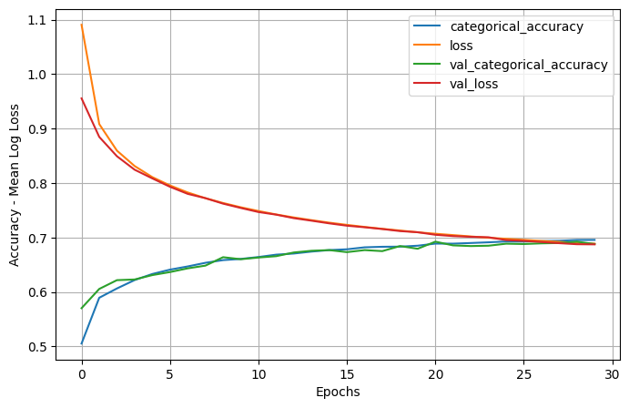

```python
visualize_history(history.history)
```

Podemos observar que con 30 épocas el modelo no ha convergido del todo. Por lo tanto, podemos continuar su entrenamiento hasta que el modelo converja

```python
new_history = first_model.fit(
    train_x,
    train_y,
    batch_size=batch_size,
    epochs=100,  # 100 mas
    verbose=1,
    validation_data=(validation_x, validation_y)
)
```

```
202/202 ━━━━━━━━━━━━━━━━━━━━ 0s 854us/step - categorical_accuracy: 0.6966 - loss: 0.6874 - val_categorical_accuracy: 0.6888 - val_loss: 0.6856
202/202 ━━━━━━━━━━━━━━━━━━━━ 0s 752us/step - categorical_accuracy: 0.6962 - loss: 0.6858 - val_categorical_accuracy: 0.6925 - val_loss: 0.6842
202/202 ━━━━━━━━━━━━━━━━━━━━ 0s 739us/step - categorical_accuracy: 0.6976 - loss: 0.6847 - val_categorical_accuracy: 0.6937 - val_loss: 0.6820
202/202 ━━━━━━━━━━━━━━━━━━━━ 0s 796us/step - categorical_accuracy: 0.6972 - loss: 0.6834 - val_categorical_accuracy: 0.6950 - val_loss: 0.6810
202/202 ━━━━━━━━━━━━━━━━━━━━ 0s 803us/step - categorical_accuracy: 0.6976 - loss: 0.6821 - val_categorical_accuracy: 0.6931 - val_loss: 0.6792
202/202 ━━━━━━━━━━━━━━━━━━━━ 0s 764us/step - categorical_accuracy: 0.6999 - loss: 0.6809 - val_categorical_accuracy: 0.6919 - val_loss: 0.6782
202/202 ━━━━━━━━━━━━━━━━━━━━ 0s 791us/step - categorical_accuracy: 0.7004 - loss: 0.6799 - val_categorical_accuracy: 0.6956 - val_loss: 0.6771
202/202 ━━━━━━━━━━━━━━━━━━━━ 0s 747us/step - categorical_accuracy: 0.7006 - loss: 0.6788 - val_categorical_accuracy: 0.6981 - val_loss: 0.6752
202/202 ━━━━━━━━━━━━━━━━━━━━ 0s 743us/step - categorical_accuracy: 0.7016 - loss: 0.6778 - val_categorical_accuracy: 0.6931 - val_loss: 0.6766
202/202 ━━━━━━━━━━━━━━━━━━━━ 0s 805us/step - categorical_accuracy: 0.7006 - loss: 0.6769 - val_categorical_accuracy: 0.6975 - val_loss: 0.6744
202/202 ━━━━━━━━━━━━━━━━━━━━ 0s 771us/step - categorical_accuracy: 0.7017 - loss: 0.6760 - val_categorical_accuracy: 0.6950 - val_loss: 0.6727
202/202 ━━━━━━━━━━━━━━━━━━━━ 0s 798us/step - categorical_accuracy: 0.7013 - loss: 0.6751 - val_categorical_accuracy: 0.6962 - val_loss: 0.6716
202/202 ━━━━━━━━━━━━━━━━━━━━ 0s 798us/step - categorical_accuracy: 0.7017 - loss: 0.6742 - val_categorical_accuracy: 0.6956 - val_loss: 0.6701
202/202 ━━━━━━━━━━━━━━━━━━━━ 0s 771us/step - categorical_accuracy: 0.7020 - loss: 0.6736 - val_categorical_accuracy: 0.6962 - val_loss: 0.6696
202/202 ━━━━━━━━━━━━━━━━━━━━ 0s 790us/step - categorical_accuracy: 0.7036 - loss: 0.6727 - val_categorical_accuracy: 0.6962 - val_loss: 0.6701
202/202 ━━━━━━━━━━━━━━━━━━━━ 0s 775us/step - categorical_accuracy: 0.7025 - loss: 0.6720 - val_categorical_accuracy: 0.6962 - val_loss: 0.6681
202/202 ━━━━━━━━━━━━━━━━━━━━ 0s 754us/step - categorical_accuracy: 0.7033 - loss: 0.6711 - val_categorical_accuracy: 0.6975 - val_loss: 0.6680
202/202 ━━━━━━━━━━━━━━━━━━━━ 0s 808us/step - categorical_accuracy: 0.7034 - loss: 0.6705 - val_categorical_accuracy: 0.6956 - val_loss: 0.6672
202/202 ━━━━━━━━━━━━━━━━━━━━ 0s 807us/step - categorical_accuracy: 0.7033 - loss: 0.6699 - val_categorical_accuracy: 0.6975 - val_loss: 0.6655
202/202 ━━━━━━━━━━━━━━━━━━━━ 0s 797us/step - categorical_accuracy: 0.7036 - loss: 0.6692 - val_categorical_accuracy: 0.6968 - val_loss: 0.6651
202/202 ━━━━━━━━━━━━━━━━━━━━ 0s 768us/step - categorical_accuracy: 0.7041 - loss: 0.6686 - val_categorical_accuracy: 0.6999 - val_loss: 0.6645
202/202 ━━━━━━━━━━━━━━━━━━━━ 0s 776us/step - categorical_accuracy: 0.7049 - loss: 0.6680 - val_categorical_accuracy: 0.6962 - val_loss: 0.6638
202/202 ━━━━━━━━━━━━━━━━━━━━ 0s 785us/step - categorical_accuracy: 0.7033 - loss: 0.6675 - val_categorical_accuracy: 0.6987 - val_loss: 0.6633
202/202 ━━━━━━━━━━━━━━━━━━━━ 0s 800us/step - categorical_accuracy: 0.7052 - loss: 0.6669 - val_categorical_accuracy: 0.6962 - val_loss: 0.6635
202/202 ━━━━━━━━━━━━━━━━━━━━ 0s 771us/step - categorical_accuracy: 0.7051 - loss: 0.6664 - val_categorical_accuracy: 0.6981 - val_loss: 0.6618
202/202 ━━━━━━━━━━━━━━━━━━━━ 0s 763us/step - categorical_accuracy: 0.7048 - loss: 0.6660 - val_categorical_accuracy: 0.6987 - val_loss: 0.6616
202/202 ━━━━━━━━━━━━━━━━━━━━ 0s 762us/step - categorical_accuracy: 0.7054 - loss: 0.6654 - val_categorical_accuracy: 0.7006 - val_loss: 0.6610
202/202 ━━━━━━━━━━━━━━━━━━━━ 0s 760us/step - categorical_accuracy: 0.7060 - loss: 0.6650 - val_categorical_accuracy: 0.6962 - val_loss: 0.6601
202/202 ━━━━━━━━━━━━━━━━━━━━ 0s 785us/step - categorical_accuracy: 0.7054 - loss: 0.6645 - val_categorical_accuracy: 0.7006 - val_loss: 0.6597
202/202 ━━━━━━━━━━━━━━━━━━━━ 0s 771us/step - categorical_accuracy: 0.7063 - loss: 0.6640 - val_categorical_accuracy: 0.6975 - val_loss: 0.6591
202/202 ━━━━━━━━━━━━━━━━━━━━ 0s 753us/step - categorical_accuracy: 0.7063 - loss: 0.6637 - val_categorical_accuracy: 0.7006 - val_loss: 0.6584
202/202 ━━━━━━━━━━━━━━━━━━━━ 0s 788us/step - categorical_accuracy: 0.7057 - loss: 0.6631 - val_categorical_accuracy: 0.7006 - val_loss: 0.6587
202/202 ━━━━━━━━━━━━━━━━━━━━ 0s 767us/step - categorical_accuracy: 0.7054 - loss: 0.6626 - val_categorical_accuracy: 0.6993 - val_loss: 0.6577
202/202 ━━━━━━━━━━━━━━━━━━━━ 0s 761us/step - categorical_accuracy: 0.7052 - loss: 0.6626 - val_categorical_accuracy: 0.6999 - val_loss: 0.6571
202/202 ━━━━━━━━━━━━━━━━━━━━ 0s 760us/step - categorical_accuracy: 0.7057 - loss: 0.6620 - val_categorical_accuracy: 0.7006 - val_loss: 0.6568
202/202 ━━━━━━━━━━━━━━━━━━━━ 0s 748us/step - categorical_accuracy: 0.7054 - loss: 0.6617 - val_categorical_accuracy: 0.6999 - val_loss: 0.6567
202/202 ━━━━━━━━━━━━━━━━━━━━ 0s 762us/step - categorical_accuracy: 0.7050 - loss: 0.6612 - val_categorical_accuracy: 0.6975 - val_loss: 0.6558
202/202 ━━━━━━━━━━━━━━━━━━━━ 0s 737us/step - categorical_accuracy: 0.7064 - loss: 0.6609 - val_categorical_accuracy: 0.7012 - val_loss: 0.6566
202/202 ━━━━━━━━━━━━━━━━━━━━ 0s 756us/step - categorical_accuracy: 0.7046 - loss: 0.6607 - val_categorical_accuracy: 0.7018 - val_loss: 0.6553
202/202 ━━━━━━━━━━━━━━━━━━━━ 0s 767us/step - categorical_accuracy: 0.7057 - loss: 0.6603 - val_categorical_accuracy: 0.7018 - val_loss: 0.6554
```

[output cut: 45 more lines]

```
202/202 ━━━━━━━━━━━━━━━━━━━━ 0s 791us/step - categorical_accuracy: 0.7078 - loss: 0.6521 - val_categorical_accuracy: 0.7024 - val_loss: 0.6451
202/202 ━━━━━━━━━━━━━━━━━━━━ 0s 760us/step - categorical_accuracy: 0.7062 - loss: 0.6520 - val_categorical_accuracy: 0.7006 - val_loss: 0.6443
202/202 ━━━━━━━━━━━━━━━━━━━━ 0s 773us/step - categorical_accuracy: 0.7078 - loss: 0.6520 - val_categorical_accuracy: 0.6999 - val_loss: 0.6454
202/202 ━━━━━━━━━━━━━━━━━━━━ 0s 705us/step - categorical_accuracy: 0.7078 - loss: 0.6520 - val_categorical_accuracy: 0.7018 - val_loss: 0.6443
202/202 ━━━━━━━━━━━━━━━━━━━━ 0s 752us/step - categorical_accuracy: 0.7066 - loss: 0.6517 - val_categorical_accuracy: 0.7012 - val_loss: 0.6461
202/202 ━━━━━━━━━━━━━━━━━━━━ 0s 746us/step - categorical_accuracy: 0.7079 - loss: 0.6517 - val_categorical_accuracy: 0.7030 - val_loss: 0.6448
202/202 ━━━━━━━━━━━━━━━━━━━━ 0s 771us/step - categorical_accuracy: 0.7069 - loss: 0.6517 - val_categorical_accuracy: 0.7030 - val_loss: 0.6449
202/202 ━━━━━━━━━━━━━━━━━━━━ 0s 765us/step - categorical_accuracy: 0.7055 - loss: 0.6515 - val_categorical_accuracy: 0.6993 - val_loss: 0.6447
202/202 ━━━━━━━━━━━━━━━━━━━━ 0s 793us/step - categorical_accuracy: 0.7061 - loss: 0.6516 - val_categorical_accuracy: 0.7012 - val_loss: 0.6447
202/202 ━━━━━━━━━━━━━━━━━━━━ 0s 757us/step - categorical_accuracy: 0.7063 - loss: 0.6514 - val_categorical_accuracy: 0.7024 - val_loss: 0.6438
202/202 ━━━━━━━━━━━━━━━━━━━━ 0s 762us/step - categorical_accuracy: 0.7078 - loss: 0.6512 - val_categorical_accuracy: 0.7043 - val_loss: 0.6439
202/202 ━━━━━━━━━━━━━━━━━━━━ 0s 761us/step - categorical_accuracy: 0.7071 - loss: 0.6511 - val_categorical_accuracy: 0.7006 - val_loss: 0.6441
202/202 ━━━━━━━━━━━━━━━━━━━━ 0s 756us/step - categorical_accuracy: 0.7073 - loss: 0.6513 - val_categorical_accuracy: 0.7018 - val_loss: 0.6445
202/202 ━━━━━━━━━━━━━━━━━━━━ 0s 777us/step - categorical_accuracy: 0.7074 - loss: 0.6512 - val_categorical_accuracy: 0.7024 - val_loss: 0.6434
202/202 ━━━━━━━━━━━━━━━━━━━━ 0s 759us/step - categorical_accuracy: 0.7067 - loss: 0.6510 - val_categorical_accuracy: 0.7018 - val_loss: 0.6440
```

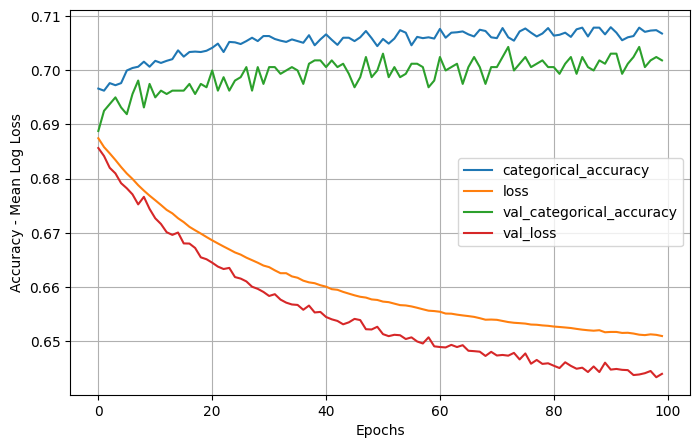

```python
visualize_history(new_history.history)
```

En base al accuracy podemos decir que el modelo ha convergido y su rendimiento no mejora. Para saber si podemos mejorar el rendimiento de nuestro modelo, vamos a añadir capas ocultas.

Como función de activación vamos a utilizar ReLU, para la inicialización de los pesos usaremos He y para optimizar usaremos Adam. No vamos a utilizar de momento ningún método para la estabilización del entrenamiento o prevención de overfitting.

```python
second_model = models.Sequential([
  layers.InputLayer(shape=(INPUTS,)),

  layers.Dense(
    64,
    activation="relu",
    kernel_initializer="he_normal"
  ),
  layers.Dense(
    32,
    activation="relu",
    kernel_initializer="he_normal"
  ),
  layers.Dense(
    16,
    activation="relu",
    kernel_initializer="he_normal"
  ),

  layers.Dense(
    OUTPUTS,
    activation="softmax",
    kernel_initializer="he_normal",
  ),
])
```

```python
second_model.compile(
    loss=losses.categorical_crossentropy,
    optimizer=optimizers.Adam(
        learning_rate=0.001,
        beta_1=0.9,
        beta_2=0.999
    ),
    metrics=["categorical_accuracy"]
)

history = second_model.fit(
    train_x,
    train_y,
    batch_size=batch_size,
    epochs=n_epochs,
    verbose=1,
    validation_data=(validation_x, validation_y)
)
```

[output not shown]

[output cut: 45 more lines]

[output not shown]

[figure not shown]

```python
visualize_history(history.history)
```

En la visualización del accuracy y loss de los conjuntos de entrenamiento y validación podemos ver que las métricas del conjunto de validación no mejoran, mientras que las de entrenamiento si. Por lo tanto, podemos decir que se produce un sobreajuste.

Podríamos seleccionar un modelo que tenia el mejor resultado sobre el conjunto de validación, pero vamos a intentar combatir el sobreajuste para ver si podemos llegar a un rendimiento mejor.

Vamos a empezar introduciendo regularización

```python
from keras import regularizers

regularization = 0.001

third_model = models.Sequential([
  layers.InputLayer(shape=(INPUTS,)),

  layers.Dense(
      64,
      activation="relu",
      kernel_initializer="he_normal",
      kernel_regularizer=regularizers.L2(regularization)
  ),
  layers.Dense(
      32,
      activation="relu",
      kernel_initializer="he_normal",
      kernel_regularizer=regularizers.L2(regularization)
  ),
  layers.Dense(
      16,
      activation="relu",
      kernel_initializer="he_normal",
      kernel_regularizer=regularizers.L2(regularization)
  ),

  layers.Dense(
      OUTPUTS,
      activation="softmax",
      kernel_initializer="he_normal",
  ),
])
```

```python
n_epochs = 100

third_model.compile(
    loss=losses.categorical_crossentropy,
    optimizer=optimizers.Adam(
        learning_rate=0.001,
        beta_1=0.9,
        beta_2=0.999
    ),
    metrics=["categorical_accuracy"]
)

history = third_model.fit(
    train_x,
    train_y,
    batch_size=batch_size,
    epochs=n_epochs,
    verbose=1,
    validation_data=(validation_x, validation_y)
)
```

```
202/202 ━━━━━━━━━━━━━━━━━━━━ 1s 1ms/step - categorical_accuracy: 0.5979 - loss: 1.0998 - val_categorical_accuracy: 0.7402 - val_loss: 0.8108
202/202 ━━━━━━━━━━━━━━━━━━━━ 0s 842us/step - categorical_accuracy: 0.7659 - loss: 0.7281 - val_categorical_accuracy: 0.8159 - val_loss: 0.6305
202/202 ━━━━━━━━━━━━━━━━━━━━ 0s 827us/step - categorical_accuracy: 0.8186 - loss: 0.6050 - val_categorical_accuracy: 0.8301 - val_loss: 0.5563
202/202 ━━━━━━━━━━━━━━━━━━━━ 0s 816us/step - categorical_accuracy: 0.8356 - loss: 0.5461 - val_categorical_accuracy: 0.8332 - val_loss: 0.5206
202/202 ━━━━━━━━━━━━━━━━━━━━ 0s 838us/step - categorical_accuracy: 0.8451 - loss: 0.5136 - val_categorical_accuracy: 0.8487 - val_loss: 0.5009
202/202 ━━━━━━━━━━━━━━━━━━━━ 0s 831us/step - categorical_accuracy: 0.8515 - loss: 0.4943 - val_categorical_accuracy: 0.8475 - val_loss: 0.4895
202/202 ━━━━━━━━━━━━━━━━━━━━ 0s 847us/step - categorical_accuracy: 0.8542 - loss: 0.4795 - val_categorical_accuracy: 0.8444 - val_loss: 0.4797
202/202 ━━━━━━━━━━━━━━━━━━━━ 0s 857us/step - categorical_accuracy: 0.8581 - loss: 0.4669 - val_categorical_accuracy: 0.8462 - val_loss: 0.4664
202/202 ━━━━━━━━━━━━━━━━━━━━ 0s 845us/step - categorical_accuracy: 0.8526 - loss: 0.4577 - val_categorical_accuracy: 0.8481 - val_loss: 0.4586
202/202 ━━━━━━━━━━━━━━━━━━━━ 0s 852us/step - categorical_accuracy: 0.8554 - loss: 0.4553 - val_categorical_accuracy: 0.8413 - val_loss: 0.4678
202/202 ━━━━━━━━━━━━━━━━━━━━ 0s 830us/step - categorical_accuracy: 0.8578 - loss: 0.4445 - val_categorical_accuracy: 0.8537 - val_loss: 0.4431
202/202 ━━━━━━━━━━━━━━━━━━━━ 0s 834us/step - categorical_accuracy: 0.8595 - loss: 0.4349 - val_categorical_accuracy: 0.8481 - val_loss: 0.4404
202/202 ━━━━━━━━━━━━━━━━━━━━ 0s 842us/step - categorical_accuracy: 0.8619 - loss: 0.4300 - val_categorical_accuracy: 0.8506 - val_loss: 0.4375
202/202 ━━━━━━━━━━━━━━━━━━━━ 0s 832us/step - categorical_accuracy: 0.8643 - loss: 0.4233 - val_categorical_accuracy: 0.8555 - val_loss: 0.4322
202/202 ━━━━━━━━━━━━━━━━━━━━ 0s 828us/step - categorical_accuracy: 0.8609 - loss: 0.4208 - val_categorical_accuracy: 0.8599 - val_loss: 0.4220
202/202 ━━━━━━━━━━━━━━━━━━━━ 0s 847us/step - categorical_accuracy: 0.8640 - loss: 0.4147 - val_categorical_accuracy: 0.8425 - val_loss: 0.4341
202/202 ━━━━━━━━━━━━━━━━━━━━ 0s 827us/step - categorical_accuracy: 0.8656 - loss: 0.4098 - val_categorical_accuracy: 0.8549 - val_loss: 0.4203
202/202 ━━━━━━━━━━━━━━━━━━━━ 0s 839us/step - categorical_accuracy: 0.8642 - loss: 0.4074 - val_categorical_accuracy: 0.8586 - val_loss: 0.4117
202/202 ━━━━━━━━━━━━━━━━━━━━ 0s 839us/step - categorical_accuracy: 0.8668 - loss: 0.4024 - val_categorical_accuracy: 0.8568 - val_loss: 0.4158
202/202 ━━━━━━━━━━━━━━━━━━━━ 0s 868us/step - categorical_accuracy: 0.8691 - loss: 0.3988 - val_categorical_accuracy: 0.8586 - val_loss: 0.4065
202/202 ━━━━━━━━━━━━━━━━━━━━ 0s 852us/step - categorical_accuracy: 0.8674 - loss: 0.3978 - val_categorical_accuracy: 0.8586 - val_loss: 0.4146
202/202 ━━━━━━━━━━━━━━━━━━━━ 0s 831us/step - categorical_accuracy: 0.8645 - loss: 0.3959 - val_categorical_accuracy: 0.8562 - val_loss: 0.4059
202/202 ━━━━━━━━━━━━━━━━━━━━ 0s 835us/step - categorical_accuracy: 0.8665 - loss: 0.3906 - val_categorical_accuracy: 0.8568 - val_loss: 0.4045
202/202 ━━━━━━━━━━━━━━━━━━━━ 0s 829us/step - categorical_accuracy: 0.8660 - loss: 0.3899 - val_categorical_accuracy: 0.8574 - val_loss: 0.4085
202/202 ━━━━━━━━━━━━━━━━━━━━ 0s 840us/step - categorical_accuracy: 0.8696 - loss: 0.3843 - val_categorical_accuracy: 0.8611 - val_loss: 0.3928
202/202 ━━━━━━━━━━━━━━━━━━━━ 0s 846us/step - categorical_accuracy: 0.8708 - loss: 0.3815 - val_categorical_accuracy: 0.8624 - val_loss: 0.3894
202/202 ━━━━━━━━━━━━━━━━━━━━ 0s 829us/step - categorical_accuracy: 0.8702 - loss: 0.3838 - val_categorical_accuracy: 0.8605 - val_loss: 0.3870
202/202 ━━━━━━━━━━━━━━━━━━━━ 0s 864us/step - categorical_accuracy: 0.8725 - loss: 0.3774 - val_categorical_accuracy: 0.8642 - val_loss: 0.3830
202/202 ━━━━━━━━━━━━━━━━━━━━ 0s 819us/step - categorical_accuracy: 0.8691 - loss: 0.3761 - val_categorical_accuracy: 0.8661 - val_loss: 0.3863
202/202 ━━━━━━━━━━━━━━━━━━━━ 0s 907us/step - categorical_accuracy: 0.8705 - loss: 0.3762 - val_categorical_accuracy: 0.8586 - val_loss: 0.3856
202/202 ━━━━━━━━━━━━━━━━━━━━ 0s 846us/step - categorical_accuracy: 0.8734 - loss: 0.3737 - val_categorical_accuracy: 0.8648 - val_loss: 0.3798
202/202 ━━━━━━━━━━━━━━━━━━━━ 0s 833us/step - categorical_accuracy: 0.8700 - loss: 0.3742 - val_categorical_accuracy: 0.8611 - val_loss: 0.3944
202/202 ━━━━━━━━━━━━━━━━━━━━ 0s 850us/step - categorical_accuracy: 0.8713 - loss: 0.3720 - val_categorical_accuracy: 0.8593 - val_loss: 0.3824
202/202 ━━━━━━━━━━━━━━━━━━━━ 0s 824us/step - categorical_accuracy: 0.8739 - loss: 0.3683 - val_categorical_accuracy: 0.8630 - val_loss: 0.3806
202/202 ━━━━━━━━━━━━━━━━━━━━ 0s 847us/step - categorical_accuracy: 0.8683 - loss: 0.3710 - val_categorical_accuracy: 0.8624 - val_loss: 0.3862
202/202 ━━━━━━━━━━━━━━━━━━━━ 0s 830us/step - categorical_accuracy: 0.8744 - loss: 0.3658 - val_categorical_accuracy: 0.8611 - val_loss: 0.3875
202/202 ━━━━━━━━━━━━━━━━━━━━ 0s 819us/step - categorical_accuracy: 0.8737 - loss: 0.3644 - val_categorical_accuracy: 0.8586 - val_loss: 0.3815
202/202 ━━━━━━━━━━━━━━━━━━━━ 0s 855us/step - categorical_accuracy: 0.8739 - loss: 0.3626 - val_categorical_accuracy: 0.8655 - val_loss: 0.3742
202/202 ━━━━━━━━━━━━━━━━━━━━ 0s 841us/step - categorical_accuracy: 0.8712 - loss: 0.3639 - val_categorical_accuracy: 0.8624 - val_loss: 0.3740
202/202 ━━━━━━━━━━━━━━━━━━━━ 0s 855us/step - categorical_accuracy: 0.8713 - loss: 0.3622 - val_categorical_accuracy: 0.8692 - val_loss: 0.3699
```

[output cut: 45 more lines]

```
202/202 ━━━━━━━━━━━━━━━━━━━━ 0s 912us/step - categorical_accuracy: 0.8781 - loss: 0.3336 - val_categorical_accuracy: 0.8624 - val_loss: 0.3506
202/202 ━━━━━━━━━━━━━━━━━━━━ 0s 849us/step - categorical_accuracy: 0.8813 - loss: 0.3302 - val_categorical_accuracy: 0.8686 - val_loss: 0.3491
202/202 ━━━━━━━━━━━━━━━━━━━━ 0s 844us/step - categorical_accuracy: 0.8798 - loss: 0.3321 - val_categorical_accuracy: 0.8636 - val_loss: 0.3502
202/202 ━━━━━━━━━━━━━━━━━━━━ 0s 872us/step - categorical_accuracy: 0.8808 - loss: 0.3305 - val_categorical_accuracy: 0.8679 - val_loss: 0.3509
202/202 ━━━━━━━━━━━━━━━━━━━━ 0s 828us/step - categorical_accuracy: 0.8815 - loss: 0.3320 - val_categorical_accuracy: 0.8667 - val_loss: 0.3462
202/202 ━━━━━━━━━━━━━━━━━━━━ 0s 866us/step - categorical_accuracy: 0.8791 - loss: 0.3298 - val_categorical_accuracy: 0.8686 - val_loss: 0.3459
202/202 ━━━━━━━━━━━━━━━━━━━━ 0s 860us/step - categorical_accuracy: 0.8811 - loss: 0.3271 - val_categorical_accuracy: 0.8686 - val_loss: 0.3470
202/202 ━━━━━━━━━━━━━━━━━━━━ 0s 835us/step - categorical_accuracy: 0.8811 - loss: 0.3280 - val_categorical_accuracy: 0.8717 - val_loss: 0.3469
202/202 ━━━━━━━━━━━━━━━━━━━━ 0s 827us/step - categorical_accuracy: 0.8811 - loss: 0.3281 - val_categorical_accuracy: 0.8723 - val_loss: 0.3472
202/202 ━━━━━━━━━━━━━━━━━━━━ 0s 845us/step - categorical_accuracy: 0.8821 - loss: 0.3279 - val_categorical_accuracy: 0.8617 - val_loss: 0.3485
202/202 ━━━━━━━━━━━━━━━━━━━━ 0s 875us/step - categorical_accuracy: 0.8805 - loss: 0.3283 - val_categorical_accuracy: 0.8710 - val_loss: 0.3412
202/202 ━━━━━━━━━━━━━━━━━━━━ 0s 867us/step - categorical_accuracy: 0.8810 - loss: 0.3273 - val_categorical_accuracy: 0.8580 - val_loss: 0.3716
202/202 ━━━━━━━━━━━━━━━━━━━━ 0s 842us/step - categorical_accuracy: 0.8802 - loss: 0.3273 - val_categorical_accuracy: 0.8655 - val_loss: 0.3534
202/202 ━━━━━━━━━━━━━━━━━━━━ 0s 847us/step - categorical_accuracy: 0.8808 - loss: 0.3268 - val_categorical_accuracy: 0.8698 - val_loss: 0.3455
202/202 ━━━━━━━━━━━━━━━━━━━━ 0s 854us/step - categorical_accuracy: 0.8847 - loss: 0.3261 - val_categorical_accuracy: 0.8704 - val_loss: 0.3433
```

```
Mean categorical accuracy:  0.8679685890674591
```

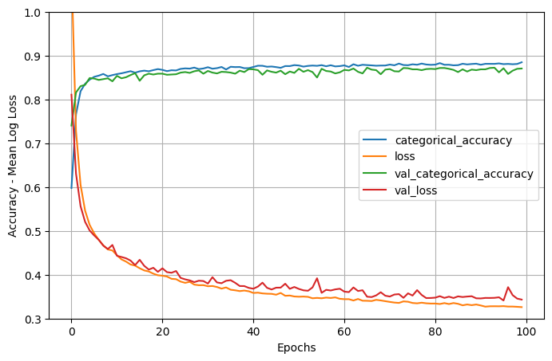

```python
import numpy as np

print("Mean categorical accuracy: ", np.mean(history.history["val_categorical_accuracy"][-30:]))
visualize_history(history.history, ylim=[0.3, 1])
```

Vemos que hemos combatido bastante el sobreajuste. Ahora las métricas del conjunto de entrenamiento y validación se parecen mucho. Además, las métricas avanzan de una manera bastante suave y progresiva convergiendo a un nivel de aproximadamente 86.8% de accuracy en el conjunto de validación.

Vamos a intentar entrenarlo un poco más para ver a que converge con un learning rate más bajo y un batch más grande

```python
n_epochs = 100

third_model.compile(
    loss=losses.categorical_crossentropy,
    optimizer=optimizers.Adam(
        learning_rate=0.0001,
        beta_1=0.9,
        beta_2=0.999
    ),
    metrics=["categorical_accuracy"]
)

history = third_model.fit(
    train_x,
    train_y,
    batch_size=batch_size * 2,
    epochs=n_epochs,
    verbose=1,
    validation_data=(validation_x, validation_y)
)
```

```
101/101 ━━━━━━━━━━━━━━━━━━━━ 1s 2ms/step - categorical_accuracy: 0.8899 - loss: 0.3139 - val_categorical_accuracy: 0.8717 - val_loss: 0.3399
101/101 ━━━━━━━━━━━━━━━━━━━━ 0s 1ms/step - categorical_accuracy: 0.8894 - loss: 0.3126 - val_categorical_accuracy: 0.8704 - val_loss: 0.3401
101/101 ━━━━━━━━━━━━━━━━━━━━ 0s 1ms/step - categorical_accuracy: 0.8895 - loss: 0.3125 - val_categorical_accuracy: 0.8710 - val_loss: 0.3401
101/101 ━━━━━━━━━━━━━━━━━━━━ 0s 1ms/step - categorical_accuracy: 0.8888 - loss: 0.3125 - val_categorical_accuracy: 0.8698 - val_loss: 0.3403
101/101 ━━━━━━━━━━━━━━━━━━━━ 0s 1ms/step - categorical_accuracy: 0.8897 - loss: 0.3124 - val_categorical_accuracy: 0.8717 - val_loss: 0.3396
101/101 ━━━━━━━━━━━━━━━━━━━━ 0s 1ms/step - categorical_accuracy: 0.8901 - loss: 0.3120 - val_categorical_accuracy: 0.8723 - val_loss: 0.3401
101/101 ━━━━━━━━━━━━━━━━━━━━ 0s 1ms/step - categorical_accuracy: 0.8903 - loss: 0.3124 - val_categorical_accuracy: 0.8710 - val_loss: 0.3399
101/101 ━━━━━━━━━━━━━━━━━━━━ 0s 1ms/step - categorical_accuracy: 0.8892 - loss: 0.3124 - val_categorical_accuracy: 0.8710 - val_loss: 0.3396
101/101 ━━━━━━━━━━━━━━━━━━━━ 0s 1ms/step - categorical_accuracy: 0.8896 - loss: 0.3118 - val_categorical_accuracy: 0.8704 - val_loss: 0.3415
101/101 ━━━━━━━━━━━━━━━━━━━━ 0s 1ms/step - categorical_accuracy: 0.8887 - loss: 0.3122 - val_categorical_accuracy: 0.8698 - val_loss: 0.3405
101/101 ━━━━━━━━━━━━━━━━━━━━ 0s 1ms/step - categorical_accuracy: 0.8897 - loss: 0.3121 - val_categorical_accuracy: 0.8692 - val_loss: 0.3404
101/101 ━━━━━━━━━━━━━━━━━━━━ 0s 1ms/step - categorical_accuracy: 0.8898 - loss: 0.3117 - val_categorical_accuracy: 0.8698 - val_loss: 0.3417
101/101 ━━━━━━━━━━━━━━━━━━━━ 0s 1ms/step - categorical_accuracy: 0.8894 - loss: 0.3121 - val_categorical_accuracy: 0.8723 - val_loss: 0.3400
101/101 ━━━━━━━━━━━━━━━━━━━━ 0s 1ms/step - categorical_accuracy: 0.8891 - loss: 0.3115 - val_categorical_accuracy: 0.8723 - val_loss: 0.3398
101/101 ━━━━━━━━━━━━━━━━━━━━ 0s 1ms/step - categorical_accuracy: 0.8901 - loss: 0.3118 - val_categorical_accuracy: 0.8723 - val_loss: 0.3406
101/101 ━━━━━━━━━━━━━━━━━━━━ 0s 1ms/step - categorical_accuracy: 0.8907 - loss: 0.3117 - val_categorical_accuracy: 0.8698 - val_loss: 0.3409
101/101 ━━━━━━━━━━━━━━━━━━━━ 0s 1ms/step - categorical_accuracy: 0.8890 - loss: 0.3112 - val_categorical_accuracy: 0.8741 - val_loss: 0.3397
101/101 ━━━━━━━━━━━━━━━━━━━━ 0s 1ms/step - categorical_accuracy: 0.8901 - loss: 0.3112 - val_categorical_accuracy: 0.8717 - val_loss: 0.3392
101/101 ━━━━━━━━━━━━━━━━━━━━ 0s 1ms/step - categorical_accuracy: 0.8894 - loss: 0.3111 - val_categorical_accuracy: 0.8729 - val_loss: 0.3391
101/101 ━━━━━━━━━━━━━━━━━━━━ 0s 1ms/step - categorical_accuracy: 0.8900 - loss: 0.3112 - val_categorical_accuracy: 0.8723 - val_loss: 0.3408
101/101 ━━━━━━━━━━━━━━━━━━━━ 0s 1ms/step - categorical_accuracy: 0.8897 - loss: 0.3110 - val_categorical_accuracy: 0.8723 - val_loss: 0.3397
101/101 ━━━━━━━━━━━━━━━━━━━━ 0s 1ms/step - categorical_accuracy: 0.8903 - loss: 0.3112 - val_categorical_accuracy: 0.8735 - val_loss: 0.3398
101/101 ━━━━━━━━━━━━━━━━━━━━ 0s 1ms/step - categorical_accuracy: 0.8904 - loss: 0.3112 - val_categorical_accuracy: 0.8729 - val_loss: 0.3393
101/101 ━━━━━━━━━━━━━━━━━━━━ 0s 1ms/step - categorical_accuracy: 0.8906 - loss: 0.3108 - val_categorical_accuracy: 0.8704 - val_loss: 0.3400
101/101 ━━━━━━━━━━━━━━━━━━━━ 0s 1ms/step - categorical_accuracy: 0.8906 - loss: 0.3110 - val_categorical_accuracy: 0.8704 - val_loss: 0.3395
101/101 ━━━━━━━━━━━━━━━━━━━━ 0s 1ms/step - categorical_accuracy: 0.8899 - loss: 0.3111 - val_categorical_accuracy: 0.8704 - val_loss: 0.3398
101/101 ━━━━━━━━━━━━━━━━━━━━ 0s 1ms/step - categorical_accuracy: 0.8894 - loss: 0.3108 - val_categorical_accuracy: 0.8704 - val_loss: 0.3406
101/101 ━━━━━━━━━━━━━━━━━━━━ 0s 1ms/step - categorical_accuracy: 0.8911 - loss: 0.3109 - val_categorical_accuracy: 0.8710 - val_loss: 0.3396
101/101 ━━━━━━━━━━━━━━━━━━━━ 0s 1ms/step - categorical_accuracy: 0.8892 - loss: 0.3107 - val_categorical_accuracy: 0.8692 - val_loss: 0.3407
101/101 ━━━━━━━━━━━━━━━━━━━━ 0s 1ms/step - categorical_accuracy: 0.8906 - loss: 0.3105 - val_categorical_accuracy: 0.8710 - val_loss: 0.3401
101/101 ━━━━━━━━━━━━━━━━━━━━ 0s 1ms/step - categorical_accuracy: 0.8904 - loss: 0.3105 - val_categorical_accuracy: 0.8723 - val_loss: 0.3403
101/101 ━━━━━━━━━━━━━━━━━━━━ 0s 1ms/step - categorical_accuracy: 0.8904 - loss: 0.3106 - val_categorical_accuracy: 0.8717 - val_loss: 0.3400
101/101 ━━━━━━━━━━━━━━━━━━━━ 0s 1ms/step - categorical_accuracy: 0.8915 - loss: 0.3107 - val_categorical_accuracy: 0.8698 - val_loss: 0.3418
101/101 ━━━━━━━━━━━━━━━━━━━━ 0s 1ms/step - categorical_accuracy: 0.8902 - loss: 0.3110 - val_categorical_accuracy: 0.8686 - val_loss: 0.3414
101/101 ━━━━━━━━━━━━━━━━━━━━ 0s 1ms/step - categorical_accuracy: 0.8901 - loss: 0.3105 - val_categorical_accuracy: 0.8710 - val_loss: 0.3403
101/101 ━━━━━━━━━━━━━━━━━━━━ 0s 1ms/step - categorical_accuracy: 0.8898 - loss: 0.3102 - val_categorical_accuracy: 0.8704 - val_loss: 0.3405
101/101 ━━━━━━━━━━━━━━━━━━━━ 0s 1ms/step - categorical_accuracy: 0.8903 - loss: 0.3106 - val_categorical_accuracy: 0.8704 - val_loss: 0.3400
101/101 ━━━━━━━━━━━━━━━━━━━━ 0s 1ms/step - categorical_accuracy: 0.8909 - loss: 0.3102 - val_categorical_accuracy: 0.8704 - val_loss: 0.3407
101/101 ━━━━━━━━━━━━━━━━━━━━ 0s 1ms/step - categorical_accuracy: 0.8902 - loss: 0.3103 - val_categorical_accuracy: 0.8710 - val_loss: 0.3397
101/101 ━━━━━━━━━━━━━━━━━━━━ 0s 1ms/step - categorical_accuracy: 0.8912 - loss: 0.3104 - val_categorical_accuracy: 0.8710 - val_loss: 0.3405
```

[output cut: 45 more lines]

```
101/101 ━━━━━━━━━━━━━━━━━━━━ 0s 1ms/step - categorical_accuracy: 0.8921 - loss: 0.3083 - val_categorical_accuracy: 0.8717 - val_loss: 0.3410
101/101 ━━━━━━━━━━━━━━━━━━━━ 0s 1ms/step - categorical_accuracy: 0.8917 - loss: 0.3085 - val_categorical_accuracy: 0.8717 - val_loss: 0.3400
101/101 ━━━━━━━━━━━━━━━━━━━━ 0s 1ms/step - categorical_accuracy: 0.8913 - loss: 0.3084 - val_categorical_accuracy: 0.8710 - val_loss: 0.3400
101/101 ━━━━━━━━━━━━━━━━━━━━ 0s 1ms/step - categorical_accuracy: 0.8920 - loss: 0.3083 - val_categorical_accuracy: 0.8717 - val_loss: 0.3402
101/101 ━━━━━━━━━━━━━━━━━━━━ 0s 1ms/step - categorical_accuracy: 0.8913 - loss: 0.3085 - val_categorical_accuracy: 0.8704 - val_loss: 0.3397
101/101 ━━━━━━━━━━━━━━━━━━━━ 0s 1ms/step - categorical_accuracy: 0.8913 - loss: 0.3079 - val_categorical_accuracy: 0.8698 - val_loss: 0.3398
101/101 ━━━━━━━━━━━━━━━━━━━━ 0s 1ms/step - categorical_accuracy: 0.8915 - loss: 0.3079 - val_categorical_accuracy: 0.8704 - val_loss: 0.3400
101/101 ━━━━━━━━━━━━━━━━━━━━ 0s 1ms/step - categorical_accuracy: 0.8926 - loss: 0.3081 - val_categorical_accuracy: 0.8723 - val_loss: 0.3396
101/101 ━━━━━━━━━━━━━━━━━━━━ 0s 1ms/step - categorical_accuracy: 0.8917 - loss: 0.3079 - val_categorical_accuracy: 0.8698 - val_loss: 0.3398
101/101 ━━━━━━━━━━━━━━━━━━━━ 0s 1ms/step - categorical_accuracy: 0.8922 - loss: 0.3080 - val_categorical_accuracy: 0.8704 - val_loss: 0.3402
101/101 ━━━━━━━━━━━━━━━━━━━━ 0s 1ms/step - categorical_accuracy: 0.8919 - loss: 0.3081 - val_categorical_accuracy: 0.8698 - val_loss: 0.3405
101/101 ━━━━━━━━━━━━━━━━━━━━ 0s 1ms/step - categorical_accuracy: 0.8919 - loss: 0.3079 - val_categorical_accuracy: 0.8710 - val_loss: 0.3401
101/101 ━━━━━━━━━━━━━━━━━━━━ 0s 1ms/step - categorical_accuracy: 0.8915 - loss: 0.3077 - val_categorical_accuracy: 0.8698 - val_loss: 0.3411
101/101 ━━━━━━━━━━━━━━━━━━━━ 0s 1ms/step - categorical_accuracy: 0.8925 - loss: 0.3077 - val_categorical_accuracy: 0.8692 - val_loss: 0.3403
101/101 ━━━━━━━━━━━━━━━━━━━━ 0s 1ms/step - categorical_accuracy: 0.8930 - loss: 0.3082 - val_categorical_accuracy: 0.8710 - val_loss: 0.3399
```

```
Mean categorical accuracy:  0.8709030826886495
```

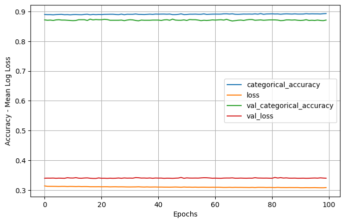

```python
print("Mean categorical accuracy: ", np.mean(history.history["val_categorical_accuracy"][-30:]))
visualize_history(history.history)
```

Vemos que el loss ha convergido y que el accuracy del conjunto de validación está un poco por debajo del de conjunto de entrenamiento.

Todavía no nos vamos a quedar con este modelo porque es posible que al aumentar la cantidad de neuronas o capas podemos llegar a un rendimiento mejor.

```python
regularization = 0.0001

forth_model = models.Sequential([
  layers.InputLayer(shape=(INPUTS,)),

  layers.Dense(
      512,
      activation="relu",
      kernel_initializer="he_normal",
      kernel_regularizer=regularizers.L2(regularization)
  ),

  layers.Dense(
      256,
      activation="relu",
      kernel_initializer="he_normal",
      kernel_regularizer=regularizers.L2(regularization)
  ),

  layers.Dense(
      128,
      activation="relu",
      kernel_initializer="he_normal",
      kernel_regularizer=regularizers.L2(regularization)
  ),

  layers.Dense(
      64,
      activation="relu",
      kernel_initializer="he_normal",
      kernel_regularizer=regularizers.L2(regularization)
  ),

  layers.Dense(
      OUTPUTS,
      kernel_initializer="he_normal",
      activation="softmax"
  ),
])
```

```python
n_epochs = 100

forth_model.compile(
    loss=losses.categorical_crossentropy,
    optimizer=optimizers.Adam(
        learning_rate=0.0001,
        beta_1=0.9,
        beta_2=0.999
    ),
    metrics=["categorical_accuracy"]
)

history = forth_model.fit(
    train_x,
    train_y,
    batch_size=batch_size * 2,
    epochs=n_epochs,
    verbose=1,
    validation_data=(validation_x, validation_y)
)
```

```
101/101 ━━━━━━━━━━━━━━━━━━━━ 1s 3ms/step - categorical_accuracy: 0.5427 - loss: 1.1868 - val_categorical_accuracy: 0.6454 - val_loss: 0.9672
101/101 ━━━━━━━━━━━━━━━━━━━━ 0s 2ms/step - categorical_accuracy: 0.6853 - loss: 0.8923 - val_categorical_accuracy: 0.7111 - val_loss: 0.8326
101/101 ━━━━━━━━━━━━━━━━━━━━ 0s 2ms/step - categorical_accuracy: 0.7242 - loss: 0.8031 - val_categorical_accuracy: 0.7433 - val_loss: 0.7698
101/101 ━━━━━━━━━━━━━━━━━━━━ 0s 2ms/step - categorical_accuracy: 0.7463 - loss: 0.7531 - val_categorical_accuracy: 0.7626 - val_loss: 0.7313
101/101 ━━━━━━━━━━━━━━━━━━━━ 0s 2ms/step - categorical_accuracy: 0.7650 - loss: 0.7167 - val_categorical_accuracy: 0.7706 - val_loss: 0.7042
101/101 ━━━━━━━━━━━━━━━━━━━━ 0s 2ms/step - categorical_accuracy: 0.7806 - loss: 0.6842 - val_categorical_accuracy: 0.7805 - val_loss: 0.6898
101/101 ━━━━━━━━━━━━━━━━━━━━ 0s 2ms/step - categorical_accuracy: 0.7929 - loss: 0.6559 - val_categorical_accuracy: 0.7861 - val_loss: 0.6616
101/101 ━━━━━━━━━━━━━━━━━━━━ 0s 3ms/step - categorical_accuracy: 0.8065 - loss: 0.6307 - val_categorical_accuracy: 0.7991 - val_loss: 0.6371
101/101 ━━━━━━━━━━━━━━━━━━━━ 0s 3ms/step - categorical_accuracy: 0.8206 - loss: 0.6039 - val_categorical_accuracy: 0.7979 - val_loss: 0.6183
101/101 ━━━━━━━━━━━━━━━━━━━━ 0s 2ms/step - categorical_accuracy: 0.8284 - loss: 0.5830 - val_categorical_accuracy: 0.8115 - val_loss: 0.6056
101/101 ━━━━━━━━━━━━━━━━━━━━ 0s 2ms/step - categorical_accuracy: 0.8393 - loss: 0.5632 - val_categorical_accuracy: 0.8091 - val_loss: 0.5980
101/101 ━━━━━━━━━━━━━━━━━━━━ 0s 2ms/step - categorical_accuracy: 0.8478 - loss: 0.5455 - val_categorical_accuracy: 0.8264 - val_loss: 0.5699
101/101 ━━━━━━━━━━━━━━━━━━━━ 0s 3ms/step - categorical_accuracy: 0.8592 - loss: 0.5283 - val_categorical_accuracy: 0.8283 - val_loss: 0.5631
101/101 ━━━━━━━━━━━━━━━━━━━━ 0s 2ms/step - categorical_accuracy: 0.8575 - loss: 0.5174 - val_categorical_accuracy: 0.8270 - val_loss: 0.5610
101/101 ━━━━━━━━━━━━━━━━━━━━ 0s 2ms/step - categorical_accuracy: 0.8651 - loss: 0.5088 - val_categorical_accuracy: 0.8208 - val_loss: 0.5543
101/101 ━━━━━━━━━━━━━━━━━━━━ 0s 3ms/step - categorical_accuracy: 0.8695 - loss: 0.4983 - val_categorical_accuracy: 0.8345 - val_loss: 0.5465
101/101 ━━━━━━━━━━━━━━━━━━━━ 0s 2ms/step - categorical_accuracy: 0.8762 - loss: 0.4874 - val_categorical_accuracy: 0.8320 - val_loss: 0.5373
101/101 ━━━━━━━━━━━━━━━━━━━━ 0s 2ms/step - categorical_accuracy: 0.8805 - loss: 0.4812 - val_categorical_accuracy: 0.8363 - val_loss: 0.5352
101/101 ━━━━━━━━━━━━━━━━━━━━ 0s 2ms/step - categorical_accuracy: 0.8790 - loss: 0.4745 - val_categorical_accuracy: 0.8394 - val_loss: 0.5350
101/101 ━━━━━━━━━━━━━━━━━━━━ 0s 2ms/step - categorical_accuracy: 0.8817 - loss: 0.4674 - val_categorical_accuracy: 0.8363 - val_loss: 0.5332
101/101 ━━━━━━━━━━━━━━━━━━━━ 0s 2ms/step - categorical_accuracy: 0.8855 - loss: 0.4630 - val_categorical_accuracy: 0.8425 - val_loss: 0.5255
101/101 ━━━━━━━━━━━━━━━━━━━━ 0s 2ms/step - categorical_accuracy: 0.8876 - loss: 0.4570 - val_categorical_accuracy: 0.8357 - val_loss: 0.5311
101/101 ━━━━━━━━━━━━━━━━━━━━ 0s 2ms/step - categorical_accuracy: 0.8847 - loss: 0.4583 - val_categorical_accuracy: 0.8431 - val_loss: 0.5279
101/101 ━━━━━━━━━━━━━━━━━━━━ 0s 2ms/step - categorical_accuracy: 0.8921 - loss: 0.4464 - val_categorical_accuracy: 0.8475 - val_loss: 0.5258
101/101 ━━━━━━━━━━━━━━━━━━━━ 0s 2ms/step - categorical_accuracy: 0.8960 - loss: 0.4404 - val_categorical_accuracy: 0.8419 - val_loss: 0.5268
101/101 ━━━━━━━━━━━━━━━━━━━━ 0s 2ms/step - categorical_accuracy: 0.8968 - loss: 0.4392 - val_categorical_accuracy: 0.8388 - val_loss: 0.5242
101/101 ━━━━━━━━━━━━━━━━━━━━ 0s 2ms/step - categorical_accuracy: 0.8953 - loss: 0.4403 - val_categorical_accuracy: 0.8419 - val_loss: 0.5329
101/101 ━━━━━━━━━━━━━━━━━━━━ 0s 2ms/step - categorical_accuracy: 0.8965 - loss: 0.4354 - val_categorical_accuracy: 0.8475 - val_loss: 0.5229
101/101 ━━━━━━━━━━━━━━━━━━━━ 0s 2ms/step - categorical_accuracy: 0.8987 - loss: 0.4294 - val_categorical_accuracy: 0.8419 - val_loss: 0.5215
101/101 ━━━━━━━━━━━━━━━━━━━━ 0s 2ms/step - categorical_accuracy: 0.9004 - loss: 0.4264 - val_categorical_accuracy: 0.8462 - val_loss: 0.5179
101/101 ━━━━━━━━━━━━━━━━━━━━ 0s 2ms/step - categorical_accuracy: 0.9049 - loss: 0.4208 - val_categorical_accuracy: 0.8481 - val_loss: 0.5166
101/101 ━━━━━━━━━━━━━━━━━━━━ 0s 2ms/step - categorical_accuracy: 0.9061 - loss: 0.4149 - val_categorical_accuracy: 0.8500 - val_loss: 0.5167
101/101 ━━━━━━━━━━━━━━━━━━━━ 0s 2ms/step - categorical_accuracy: 0.9050 - loss: 0.4167 - val_categorical_accuracy: 0.8506 - val_loss: 0.5200
101/101 ━━━━━━━━━━━━━━━━━━━━ 0s 2ms/step - categorical_accuracy: 0.9085 - loss: 0.4088 - val_categorical_accuracy: 0.8462 - val_loss: 0.5297
101/101 ━━━━━━━━━━━━━━━━━━━━ 0s 2ms/step - categorical_accuracy: 0.9080 - loss: 0.4095 - val_categorical_accuracy: 0.8345 - val_loss: 0.5457
101/101 ━━━━━━━━━━━━━━━━━━━━ 0s 2ms/step - categorical_accuracy: 0.9111 - loss: 0.4066 - val_categorical_accuracy: 0.8537 - val_loss: 0.5175
101/101 ━━━━━━━━━━━━━━━━━━━━ 0s 2ms/step - categorical_accuracy: 0.9116 - loss: 0.4014 - val_categorical_accuracy: 0.8444 - val_loss: 0.5210
101/101 ━━━━━━━━━━━━━━━━━━━━ 0s 2ms/step - categorical_accuracy: 0.9115 - loss: 0.3996 - val_categorical_accuracy: 0.8500 - val_loss: 0.5222
101/101 ━━━━━━━━━━━━━━━━━━━━ 0s 2ms/step - categorical_accuracy: 0.9162 - loss: 0.3943 - val_categorical_accuracy: 0.8475 - val_loss: 0.5345
101/101 ━━━━━━━━━━━━━━━━━━━━ 0s 2ms/step - categorical_accuracy: 0.9155 - loss: 0.3919 - val_categorical_accuracy: 0.8475 - val_loss: 0.5226
```

[output cut: 45 more lines]

```
101/101 ━━━━━━━━━━━━━━━━━━━━ 0s 2ms/step - categorical_accuracy: 0.9644 - loss: 0.2829 - val_categorical_accuracy: 0.8444 - val_loss: 0.5975
101/101 ━━━━━━━━━━━━━━━━━━━━ 0s 2ms/step - categorical_accuracy: 0.9668 - loss: 0.2793 - val_categorical_accuracy: 0.8407 - val_loss: 0.6044
101/101 ━━━━━━━━━━━━━━━━━━━━ 0s 2ms/step - categorical_accuracy: 0.9678 - loss: 0.2765 - val_categorical_accuracy: 0.8531 - val_loss: 0.5854
101/101 ━━━━━━━━━━━━━━━━━━━━ 0s 2ms/step - categorical_accuracy: 0.9695 - loss: 0.2738 - val_categorical_accuracy: 0.8345 - val_loss: 0.6031
101/101 ━━━━━━━━━━━━━━━━━━━━ 0s 2ms/step - categorical_accuracy: 0.9706 - loss: 0.2719 - val_categorical_accuracy: 0.8400 - val_loss: 0.6091
101/101 ━━━━━━━━━━━━━━━━━━━━ 0s 2ms/step - categorical_accuracy: 0.9725 - loss: 0.2689 - val_categorical_accuracy: 0.8456 - val_loss: 0.6081
101/101 ━━━━━━━━━━━━━━━━━━━━ 0s 2ms/step - categorical_accuracy: 0.9723 - loss: 0.2676 - val_categorical_accuracy: 0.8475 - val_loss: 0.5966
101/101 ━━━━━━━━━━━━━━━━━━━━ 0s 2ms/step - categorical_accuracy: 0.9728 - loss: 0.2646 - val_categorical_accuracy: 0.8425 - val_loss: 0.6063
101/101 ━━━━━━━━━━━━━━━━━━━━ 0s 2ms/step - categorical_accuracy: 0.9716 - loss: 0.2660 - val_categorical_accuracy: 0.8481 - val_loss: 0.6181
101/101 ━━━━━━━━━━━━━━━━━━━━ 0s 2ms/step - categorical_accuracy: 0.9723 - loss: 0.2666 - val_categorical_accuracy: 0.8444 - val_loss: 0.6180
101/101 ━━━━━━━━━━━━━━━━━━━━ 0s 2ms/step - categorical_accuracy: 0.9762 - loss: 0.2603 - val_categorical_accuracy: 0.8413 - val_loss: 0.6296
101/101 ━━━━━━━━━━━━━━━━━━━━ 0s 2ms/step - categorical_accuracy: 0.9768 - loss: 0.2576 - val_categorical_accuracy: 0.8462 - val_loss: 0.6204
101/101 ━━━━━━━━━━━━━━━━━━━━ 0s 2ms/step - categorical_accuracy: 0.9749 - loss: 0.2578 - val_categorical_accuracy: 0.8431 - val_loss: 0.6188
101/101 ━━━━━━━━━━━━━━━━━━━━ 0s 2ms/step - categorical_accuracy: 0.9775 - loss: 0.2551 - val_categorical_accuracy: 0.8363 - val_loss: 0.6337
101/101 ━━━━━━━━━━━━━━━━━━━━ 0s 2ms/step - categorical_accuracy: 0.9769 - loss: 0.2559 - val_categorical_accuracy: 0.8481 - val_loss: 0.6246
```

```
Mean categorical accuracy:  0.8453606188297271
```

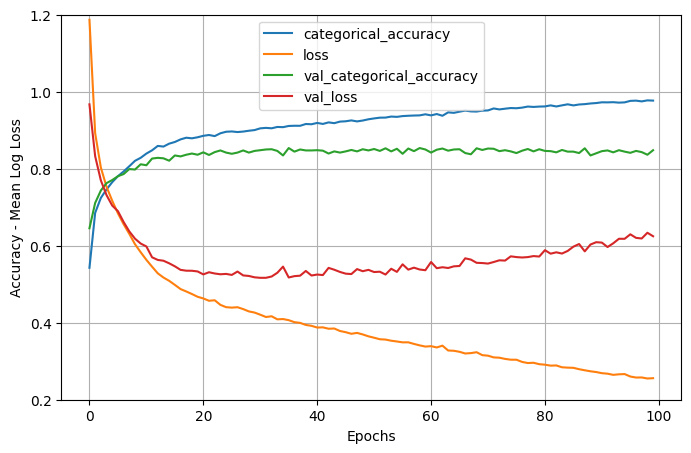

```python
print("Mean categorical accuracy: ", np.mean(history.history["val_categorical_accuracy"][-30:]))
visualize_history(history.history, ylim=[0.2, 1.2])
```

Se vuelve a producir un sobre entrenamiento. Para compensarlo, vamos a aumentar un poco la regularización y añadir dropout.

```python
regularization = 0.001
dropout_rate = 0.2

forth_model = models.Sequential([
  layers.InputLayer(shape=(INPUTS,)),

  layers.Dense(
      512,
      activation="relu",
      kernel_initializer="he_normal",
      kernel_regularizer=regularizers.L2(regularization)
  ),
  layers.Dropout(dropout_rate),

  layers.Dense(
      256,
      activation="relu",
      kernel_initializer="he_normal",
      kernel_regularizer=regularizers.L2(regularization)
  ),
  layers.Dropout(dropout_rate),

  layers.Dense(
      128,
      activation="relu",
      kernel_initializer="he_normal",
      kernel_regularizer=regularizers.L2(regularization)
  ),
  layers.Dropout(dropout_rate),

  layers.Dense(
      64,
      activation="relu",
      kernel_initializer="he_normal",
      kernel_regularizer=regularizers.L2(regularization)
  ),
  layers.Dropout(dropout_rate / 2),

  layers.Dense(
      OUTPUTS,
      kernel_initializer="he_normal",
      activation="softmax"
  ),
])
```

```python
n_epochs = 200

forth_model.compile(
    loss=losses.categorical_crossentropy,
    optimizer=optimizers.Adam(
        learning_rate=0.00005,
        beta_1=0.9,
        beta_2=0.999
    ),
    metrics=["categorical_accuracy"]
)

history = forth_model.fit(
    train_x,
    train_y,
    batch_size=batch_size * 2,
    epochs=n_epochs,
    verbose=1,
    validation_data=(validation_x, validation_y)
)
```

```
101/101 ━━━━━━━━━━━━━━━━━━━━ 1s 4ms/step - categorical_accuracy: 0.3913 - loss: 3.1173 - val_categorical_accuracy: 0.5251 - val_loss: 2.9007
101/101 ━━━━━━━━━━━━━━━━━━━━ 0s 3ms/step - categorical_accuracy: 0.5260 - loss: 2.8869 - val_categorical_accuracy: 0.5797 - val_loss: 2.7316
101/101 ━━━━━━━━━━━━━━━━━━━━ 0s 3ms/step - categorical_accuracy: 0.5727 - loss: 2.7629 - val_categorical_accuracy: 0.6342 - val_loss: 2.6221
101/101 ━━━━━━━━━━━━━━━━━━━━ 0s 3ms/step - categorical_accuracy: 0.5941 - loss: 2.6751 - val_categorical_accuracy: 0.6615 - val_loss: 2.5429
101/101 ━━━━━━━━━━━━━━━━━━━━ 0s 3ms/step - categorical_accuracy: 0.6204 - loss: 2.6070 - val_categorical_accuracy: 0.6745 - val_loss: 2.4811
101/101 ━━━━━━━━━━━━━━━━━━━━ 0s 3ms/step - categorical_accuracy: 0.6394 - loss: 2.5520 - val_categorical_accuracy: 0.6894 - val_loss: 2.4325
101/101 ━━━━━━━━━━━━━━━━━━━━ 0s 3ms/step - categorical_accuracy: 0.6531 - loss: 2.5014 - val_categorical_accuracy: 0.7068 - val_loss: 2.3882
101/101 ━━━━━━━━━━━━━━━━━━━━ 0s 3ms/step - categorical_accuracy: 0.6560 - loss: 2.4630 - val_categorical_accuracy: 0.7099 - val_loss: 2.3407
101/101 ━━━━━━━━━━━━━━━━━━━━ 0s 3ms/step - categorical_accuracy: 0.6668 - loss: 2.4228 - val_categorical_accuracy: 0.7167 - val_loss: 2.3103
101/101 ━━━━━━━━━━━━━━━━━━━━ 0s 3ms/step - categorical_accuracy: 0.6823 - loss: 2.3732 - val_categorical_accuracy: 0.7322 - val_loss: 2.2660
101/101 ━━━━━━━━━━━━━━━━━━━━ 0s 3ms/step - categorical_accuracy: 0.6825 - loss: 2.3483 - val_categorical_accuracy: 0.7365 - val_loss: 2.2357
101/101 ━━━━━━━━━━━━━━━━━━━━ 0s 3ms/step - categorical_accuracy: 0.6902 - loss: 2.3085 - val_categorical_accuracy: 0.7365 - val_loss: 2.2015
101/101 ━━━━━━━━━━━━━━━━━━━━ 0s 3ms/step - categorical_accuracy: 0.6994 - loss: 2.2759 - val_categorical_accuracy: 0.7396 - val_loss: 2.1722
101/101 ━━━━━━━━━━━━━━━━━━━━ 0s 3ms/step - categorical_accuracy: 0.7012 - loss: 2.2409 - val_categorical_accuracy: 0.7477 - val_loss: 2.1316
101/101 ━━━━━━━━━━━━━━━━━━━━ 0s 3ms/step - categorical_accuracy: 0.7079 - loss: 2.2114 - val_categorical_accuracy: 0.7551 - val_loss: 2.0979
101/101 ━━━━━━━━━━━━━━━━━━━━ 0s 3ms/step - categorical_accuracy: 0.7153 - loss: 2.1802 - val_categorical_accuracy: 0.7526 - val_loss: 2.0716
101/101 ━━━━━━━━━━━━━━━━━━━━ 0s 3ms/step - categorical_accuracy: 0.7171 - loss: 2.1517 - val_categorical_accuracy: 0.7570 - val_loss: 2.0439
101/101 ━━━━━━━━━━━━━━━━━━━━ 0s 3ms/step - categorical_accuracy: 0.7254 - loss: 2.1179 - val_categorical_accuracy: 0.7576 - val_loss: 2.0122
101/101 ━━━━━━━━━━━━━━━━━━━━ 0s 3ms/step - categorical_accuracy: 0.7264 - loss: 2.0932 - val_categorical_accuracy: 0.7582 - val_loss: 1.9917
101/101 ━━━━━━━━━━━━━━━━━━━━ 0s 3ms/step - categorical_accuracy: 0.7273 - loss: 2.0650 - val_categorical_accuracy: 0.7576 - val_loss: 1.9689
101/101 ━━━━━━━━━━━━━━━━━━━━ 0s 3ms/step - categorical_accuracy: 0.7336 - loss: 2.0336 - val_categorical_accuracy: 0.7681 - val_loss: 1.9362
101/101 ━━━━━━━━━━━━━━━━━━━━ 0s 3ms/step - categorical_accuracy: 0.7382 - loss: 2.0089 - val_categorical_accuracy: 0.7762 - val_loss: 1.9040
101/101 ━━━━━━━━━━━━━━━━━━━━ 0s 3ms/step - categorical_accuracy: 0.7439 - loss: 1.9801 - val_categorical_accuracy: 0.7762 - val_loss: 1.8802
101/101 ━━━━━━━━━━━━━━━━━━━━ 0s 3ms/step - categorical_accuracy: 0.7425 - loss: 1.9616 - val_categorical_accuracy: 0.7768 - val_loss: 1.8612
101/101 ━━━━━━━━━━━━━━━━━━━━ 0s 3ms/step - categorical_accuracy: 0.7448 - loss: 1.9365 - val_categorical_accuracy: 0.7830 - val_loss: 1.8356
101/101 ━━━━━━━━━━━━━━━━━━━━ 0s 3ms/step - categorical_accuracy: 0.7534 - loss: 1.9089 - val_categorical_accuracy: 0.7898 - val_loss: 1.8119
101/101 ━━━━━━━━━━━━━━━━━━━━ 0s 3ms/step - categorical_accuracy: 0.7542 - loss: 1.8820 - val_categorical_accuracy: 0.7923 - val_loss: 1.7871
101/101 ━━━━━━━━━━━━━━━━━━━━ 0s 3ms/step - categorical_accuracy: 0.7625 - loss: 1.8600 - val_categorical_accuracy: 0.7929 - val_loss: 1.7641
101/101 ━━━━━━━━━━━━━━━━━━━━ 0s 3ms/step - categorical_accuracy: 0.7654 - loss: 1.8361 - val_categorical_accuracy: 0.7905 - val_loss: 1.7440
101/101 ━━━━━━━━━━━━━━━━━━━━ 0s 3ms/step - categorical_accuracy: 0.7680 - loss: 1.8198 - val_categorical_accuracy: 0.8004 - val_loss: 1.7139
101/101 ━━━━━━━━━━━━━━━━━━━━ 0s 3ms/step - categorical_accuracy: 0.7676 - loss: 1.7955 - val_categorical_accuracy: 0.7954 - val_loss: 1.7066
101/101 ━━━━━━━━━━━━━━━━━━━━ 0s 3ms/step - categorical_accuracy: 0.7659 - loss: 1.7760 - val_categorical_accuracy: 0.7991 - val_loss: 1.6843
101/101 ━━━━━━━━━━━━━━━━━━━━ 0s 3ms/step - categorical_accuracy: 0.7803 - loss: 1.7494 - val_categorical_accuracy: 0.8010 - val_loss: 1.6590
101/101 ━━━━━━━━━━━━━━━━━━━━ 0s 3ms/step - categorical_accuracy: 0.7793 - loss: 1.7362 - val_categorical_accuracy: 0.8066 - val_loss: 1.6395
101/101 ━━━━━━━━━━━━━━━━━━━━ 0s 3ms/step - categorical_accuracy: 0.7848 - loss: 1.7098 - val_categorical_accuracy: 0.8109 - val_loss: 1.6212
101/101 ━━━━━━━━━━━━━━━━━━━━ 0s 3ms/step - categorical_accuracy: 0.7879 - loss: 1.6897 - val_categorical_accuracy: 0.8146 - val_loss: 1.6020
101/101 ━━━━━━━━━━━━━━━━━━━━ 0s 3ms/step - categorical_accuracy: 0.7848 - loss: 1.6757 - val_categorical_accuracy: 0.8140 - val_loss: 1.5881
101/101 ━━━━━━━━━━━━━━━━━━━━ 0s 3ms/step - categorical_accuracy: 0.7883 - loss: 1.6535 - val_categorical_accuracy: 0.8184 - val_loss: 1.5656
101/101 ━━━━━━━━━━━━━━━━━━━━ 0s 3ms/step - categorical_accuracy: 0.7883 - loss: 1.6362 - val_categorical_accuracy: 0.8171 - val_loss: 1.5530
101/101 ━━━━━━━━━━━━━━━━━━━━ 0s 3ms/step - categorical_accuracy: 0.7904 - loss: 1.6192 - val_categorical_accuracy: 0.8153 - val_loss: 1.5426
```

[output cut: 145 more lines]

```
101/101 ━━━━━━━━━━━━━━━━━━━━ 0s 3ms/step - categorical_accuracy: 0.8619 - loss: 0.6652 - val_categorical_accuracy: 0.8611 - val_loss: 0.6495
101/101 ━━━━━━━━━━━━━━━━━━━━ 0s 3ms/step - categorical_accuracy: 0.8632 - loss: 0.6667 - val_categorical_accuracy: 0.8593 - val_loss: 0.6453
101/101 ━━━━━━━━━━━━━━━━━━━━ 0s 3ms/step - categorical_accuracy: 0.8653 - loss: 0.6578 - val_categorical_accuracy: 0.8630 - val_loss: 0.6412
101/101 ━━━━━━━━━━━━━━━━━━━━ 0s 3ms/step - categorical_accuracy: 0.8663 - loss: 0.6550 - val_categorical_accuracy: 0.8624 - val_loss: 0.6405
101/101 ━━━━━━━━━━━━━━━━━━━━ 0s 3ms/step - categorical_accuracy: 0.8646 - loss: 0.6537 - val_categorical_accuracy: 0.8648 - val_loss: 0.6378
101/101 ━━━━━━━━━━━━━━━━━━━━ 0s 3ms/step - categorical_accuracy: 0.8637 - loss: 0.6526 - val_categorical_accuracy: 0.8630 - val_loss: 0.6354
101/101 ━━━━━━━━━━━━━━━━━━━━ 0s 3ms/step - categorical_accuracy: 0.8646 - loss: 0.6477 - val_categorical_accuracy: 0.8642 - val_loss: 0.6321
101/101 ━━━━━━━━━━━━━━━━━━━━ 0s 3ms/step - categorical_accuracy: 0.8650 - loss: 0.6495 - val_categorical_accuracy: 0.8611 - val_loss: 0.6315
101/101 ━━━━━━━━━━━━━━━━━━━━ 0s 3ms/step - categorical_accuracy: 0.8653 - loss: 0.6463 - val_categorical_accuracy: 0.8624 - val_loss: 0.6277
101/101 ━━━━━━━━━━━━━━━━━━━━ 0s 3ms/step - categorical_accuracy: 0.8656 - loss: 0.6424 - val_categorical_accuracy: 0.8673 - val_loss: 0.6272
101/101 ━━━━━━━━━━━━━━━━━━━━ 0s 3ms/step - categorical_accuracy: 0.8669 - loss: 0.6441 - val_categorical_accuracy: 0.8636 - val_loss: 0.6248
101/101 ━━━━━━━━━━━━━━━━━━━━ 0s 3ms/step - categorical_accuracy: 0.8649 - loss: 0.6449 - val_categorical_accuracy: 0.8642 - val_loss: 0.6245
101/101 ━━━━━━━━━━━━━━━━━━━━ 0s 3ms/step - categorical_accuracy: 0.8644 - loss: 0.6385 - val_categorical_accuracy: 0.8642 - val_loss: 0.6204
101/101 ━━━━━━━━━━━━━━━━━━━━ 0s 3ms/step - categorical_accuracy: 0.8605 - loss: 0.6414 - val_categorical_accuracy: 0.8642 - val_loss: 0.6187
101/101 ━━━━━━━━━━━━━━━━━━━━ 0s 3ms/step - categorical_accuracy: 0.8677 - loss: 0.6332 - val_categorical_accuracy: 0.8605 - val_loss: 0.6195
```

```
Mean categorical accuracy:  0.8621822694937388
```

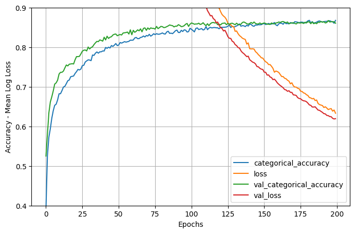

```python
print("Mean categorical accuracy: ", np.mean(history.history["val_categorical_accuracy"][-30:]))
visualize_history(history.history, ylim=[0.4, 0.9])
```

Vemos que con este modelo que es más grande y profundo, se complica obtener un accuracy mayor. Tuvimos que jugar con la regularización, dropout, learning rate, pero es complicado obtener un rendimiento mucho mayor.

Por lo tanto, ante tan poca diferencia entre el rendimiento de un modelo más simple y este modelo más complejo, hemos decido quedarnos con el modelo `third_model`. Vamos a evaluar su rendimiento con el conjunto de test.

```python
model = third_model

model.evaluate(test_x, test_y)
```

```
51/51 ━━━━━━━━━━━━━━━━━━━━ 0s 1ms/step - categorical_accuracy: 0.8798 - loss: 0.3389
```

```
[0.33891358971595764, 0.8798017501831055]
```

Vemos que el rendimiento en el conjunto de test es incluso mayor que con la validación.

Podemos concluir que el rendimiento que podemos esperar de nuestro modelo final está en torno a 88% de accuracy.

Vamos a evaluar su rendimiento.

```python
test_predictions = model.predict(test_x)

predictions = np.argmax(test_predictions,1)
labels = np.argmax(test_y, 1)

predictions[:20] == labels[:20]
```

```
51/51 ━━━━━━━━━━━━━━━━━━━━ 0s 783us/step
```

```
array([ True,  True,  True,  True,  True,  True,  True,  True, False,
        True,  True,  True,  True,  True,  True,  True, False,  True,
        True,  True])
```

```python
from collections import Counter

final_test_prediction_results=Counter(
    predictions == labels
)
final_test_prediction_results
```

```
Counter({np.True_: 1420, np.False_: 194})
```

```python
from sklearn.metrics import confusion_matrix

classes = ["Poor", "Intermediate", "Good", "Excellent"]

matrix = pd.DataFrame(
    confusion_matrix(predictions, labels),
    columns=classes
)
matrix.insert(0, "Classes", classes)
matrix["Sum"] = matrix.sum(axis=1, numeric_only=True)
matrix
```

|  | Classes | Poor | Intermediate | Good | Excellent | Sum |
| --- | --- | --- | --- | --- | --- | --- |
| 0 | Poor | 408 | 21 | 0 | 0 | 429 |
| 1 | Intermediate | 29 | 326 | 48 | 0 | 403 |
| 2 | Good | 0 | 43 | 353 | 30 | 426 |
| 3 | Excellent | 0 | 0 | 23 | 333 | 356 |

```python
from sklearn.metrics import classification_report

print(
    classification_report(predictions, labels, target_names=classes)
)
```

```
              precision    recall  f1-score   support

        Poor       0.93      0.95      0.94       429
Intermediate       0.84      0.81      0.82       403
        Good       0.83      0.83      0.83       426
   Excellent       0.92      0.94      0.93       356

    accuracy                           0.88      1614
   macro avg       0.88      0.88      0.88      1614
weighted avg       0.88      0.88      0.88      1614
```